# Fake News Data Analysis Project

Alaleh Ahmadian

April 16, 2018

## Packages

packages below are for tidying data, removing outliers, plotting, graphing and doing statistical analysis.

```r
library(readr)
library(dplyr)
library(readxl)
library(ggplot2)
library(dplyr)
library(stringi)
library(stringr)
library(lubridate)
library(gutenbergr)
library(highcharter)
library(tidyr)
library(tidytext)
library(boot)
library(magrittr)
library(knitr)
library(car)
library(corrplot)
library(RColorBrewer)
library(highcharter)
library(hexbin)
library(ggplot2)
library(syuzhet)
library(party)
library(randomForest)
library(gridExtra)
library(reshape2)
library(Hmisc)
library(GGally)
library(corpcor)
library(mctest)
library(wordcloud)
library(flextable)
library(kableExtra)
library(rpart)
library(rpart.plot)
library(tidyverse)
library(tidytext)
library(topicmodels) # for LDA topic modelling
library(tm)
library(SnowballC) # for stemming
library(googlesheets)
library(lubridate)
library(tidyverse)
library(kernlab)
library(NLP)
library(gtrendsR)
library(slam)
library(e1071)
```

## Data

```r
fakes1 <- read.csv("C:/Users/Alaleh/Desktop/fake.csv", stringsAsFactors = F)
fakes2 <- read.csv("C:/Users/Alaleh/Desktop/facebook-facts.csv", stringsAsFactors = F)
fakes3 <- read.csv("C:/Users/Alaleh/Desktop/fake_or_real_news.csv", stringsAsFactors = F)  #Data from George McIntire's github page
```

## Functions

In natural language processing, latent Dirichlet allocation (LDA) is a generative statistical model that allows sets of observations to be explained by unobserved groups that explain why some parts of the data are similar. For example, if observations are words collected into documents, it posits that each document is a mixture of a small number of topics and that each word’s creation is attributable to one of the document’s topics. LDA is an example of a topic model Here’s a function to get & plot the most informative terms by a specificed number of topics, using LDA

the function arguments are a dataframe column to work on, whether or not the function returns a plot and number of topics. then we create a corpus (type of object expected by tm) and document term matrix to get the count of words/document. After that remove any empty rows in our document term matrix (if there are any we’ll get an error when we try to run our LDA)

Next we can preform LDA & get the words/topic in a tidy text format

```r
top_terms_by_topic_LDA <- function(input_text, plot = T, number_of_topics = 4)
{
    Corpus <- Corpus(VectorSource(input_text))
    DTM <- DocumentTermMatrix(Corpus)
    unique_indexes <- unique(DTM$i)
    DTM <- DTM[unique_indexes,]

    lda <- LDA(DTM, k = number_of_topics, control = list(seed = 2222))
    topics <- tidy(lda, matrix = "beta")

    top_terms <- topics  %>% group_by(topic) %>%
      top_n(10, beta) %>% ungroup() %>% arrange(topic, -beta)

    if(plot == T){
        top_terms %>%
          mutate(term = reorder(term, beta)) %>%
          ggplot(aes(term, beta, fill = factor(topic))) +
          geom_col(show.legend = FALSE) + facet_wrap(~ topic, scales = "free") +
          labs(x = NULL, y = "Beta") + coord_flip()
    }else{
        return(top_terms)
    }
}
```

# Code Explanation

# TF-IDF

In information retrieval, tf-idf or TFIDF, short for term frequency-inverse document frequency, is a numerical statistic that is intended to reflect how important a word is to a document in a collection or corpus.

It is often used as a weighting factor in searches of information retrieval, text mining, and user modeling. The tf-idf value increases proportionally to the number of times a word appears in the document and is offset by the frequency of the word in the corpus, which helps to adjust for the fact that some words appear more frequently in general. Tf-idf is one of the most popular term-weighting schemes today; 83% of text-based recommender systems in digital libraries use tf-idf.

Variations of the tf-idf weighting scheme are often used by search engines as a central tool in scoring and ranking a document’s relevance given a user query. tf-idf can be successfully used for stop-words filtering in various subject fields, including text summarization and classification.

One of the simplest ranking functions is computed by summing the tf-idf for each query term; many more sophisticated ranking functions are variants of this simple model.

# Term frequency

Suppose we have a set of English text documents and wish to rank which document is most relevant to the query, “the brown cow”. A simple way to start out is by eliminating documents that do not contain all three words “the”, “brown”, and “cow”, but this still leaves many documents. To further distinguish them, we might count the number of times each term occurs in each document; the number of times a term occurs in a document is called its term frequency. However, in the case where the length of documents varies greatly, adjustments are often made (see definition below). The first form of term weighting is due to Hans Peter Luhn (1957) which may be summarized as:

The weight of a term that occurs in a document is simply proportional to the term frequency.

# Inverse document frequency

Because the term “the” is so common, term frequency will tend to incorrectly emphasize documents which happen to use the word “the” more frequently, without giving enough weight to the more meaningful terms “brown” and “cow”. The term “the” is not a good keyword to distinguish relevant and non-relevant documents and terms, unlike the less-common words “brown” and “cow”. Hence an inverse document frequency factor is incorporated which diminishes the weight of terms that occur very frequently in the document set and increases the weight of terms that occur rarely.

Karen Spärck Jones (1972) conceived a statistical interpretation of term specificity called Inverse Document Frequency (IDF), which became a cornerstone of term weighting:

The specificity of a term can be quantified as an inverse function of the number of documents in which it occurs

This function takes in a dataframe and the name of the columns with the document texts and the topic labels. If plot is set to false it will return the tf-idf output rather than a plot.

```r
top_terms_by_topic_tfidf <- function(text_df=fakes1, text_column, group_column, plot=T){

  group_column <- enquo(group_column)
  text_column <- enquo(text_column)

  words <- text_df %>% unnest_tokens(word, !!text_column) %>% count(!!group_column, word) %>% ungroup()

  total_words <- words %>% group_by(!!group_column) %>% summarise(total = sum(n))
  words <- left_join(words, total_words)

  tf_idf <- words %>% bind_tf_idf(word, !!group_column, n) %>%
    select(-total) %>% arrange(desc(tf_idf)) %>% mutate(word = factor(word, levels = rev(unique(word))))

    if(plot == T){
      group_name <- quo_name(group_column)
      tf_idf %>% group_by(!!group_column) %>% top_n(10) %>% ungroup %>%
        ggplot(aes(word, tf_idf, fill = as.factor(group_name))) + geom_col(show.legend = FALSE) +
        labs(x = NULL, y = "tf-idf") + facet_wrap(reformulate(group_name), scales = "free") +
        coord_flip()
    }
    else{
        return(tf_idf)
    }
}
```

# Code Explanation

enquo() takes a symbol referring to a function argument, quotes the R code that was supplied to this argument, captures the environment where the function was called (and thus where the R code was typed), and bundles them in a quosure. Quosures are quoted expressions that keep track of an environment (just like closurefunctions). They are implemented as a subclass of one-sided formulas. They are an essential piece of the tidy evaluation framework.

Function replaces all columns which have the value of NA with some prechosen string that we decide. (This is good for factoring and getting rid of NA values)

```r
na.replace <- function(x, repstring){
  x[is.na(x)] <- repstring
  x
}
```

## Check most used words

Since the data is too big we start with a subset, we set a seed to always get the same subset

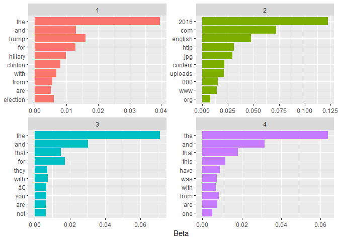

```r
set.seed(2222)

top_terms_by_topic_LDA(fakes1[sample(nrow(fakes1), 2000), ], number_of_topics = 4)
```

```r
newsCorpus <- Corpus(VectorSource(fakes1$text))
newsDTM <- DocumentTermMatrix(newsCorpus)

newsDTM_tidy <- tidy(newsDTM)
newsDTM_cleaned <- newsDTM_tidy %>% anti_join(stop_words, by = c("term" = "word"))

cleaned_documents <- newsDTM_cleaned %>% group_by(document) %>%
  mutate(terms = toString(rep(term, count))) %>% select(document, terms) %>% unique()

head(cleaned_documents)
```

```
## # A tibble: 6 x 2
## # Groups:   document [6]
##   document terms
##   <chr>    <chr>
## 1 1        asap, benefits, bust, commit, control, deported, entire, famil~
## 2 2        "100percentfedup, 2016, 5th, accusations, administration, admi~
## 3 3        "abedin, agreement, air, anthony, anthony, baier, based, break~
## 4 4        believes, carl, chance, donald, drop, email, epic, father, hea~
## 5 5        100, 2010, abetted, act, actâ, afford, affordable, allowed, a~
## 6 6        "2016, 2016, 2016, 2gpjps1eqb, absolutely, absolutely, alicia,~
```

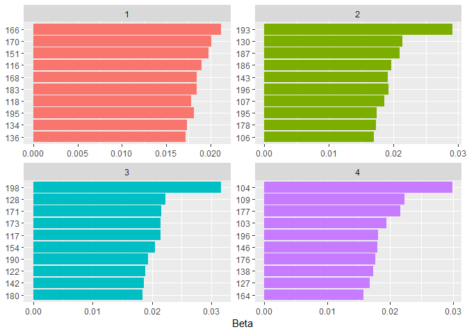

```r
newsDTM_cleaned <- newsDTM_cleaned %>% mutate(stem = wordStem(term))

cleaned_documents <- newsDTM_cleaned %>% group_by(document) %>%
    mutate(terms = toString(rep(stem, count))) %>%
    select(document, terms) %>% unique()

fakes1ch = fakes1
fakes1ch$language = as.character(fakes1ch$language)
fakes1ch$type = as.character(fakes1ch$type)
sub_samp= sample(cleaned_documents$terms,200)
top_terms_by_topic_LDA(data.frame(sub_samp))
```

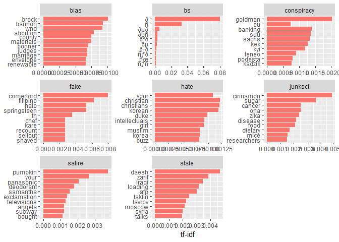

```r
top_terms_by_topic_tfidf(text_df = fakes1ch[sample(nrow(fakes1ch), 2000), ], text_column = text,group_column = type, plot = T)
```

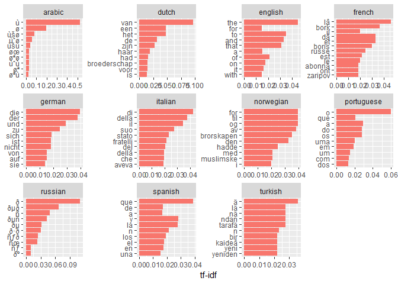

```r
top_terms_by_topic_tfidf(text_df = fakes1ch[sample(nrow(fakes1ch), 2000), ], text_column = text,group_column = language, plot = T)
```

## Checking interactions with news

Do fake news get more like, shares or comments?

```r
fakes2 %>% select(Page, Post.Type, Rating, share_count, reaction_count, comment_count) -> fakes2_data

fakes2_data[is.na(fakes2_data)] = 0

fakes2_data %>% group_by(Rating) %>% summarise(sharesum = sum(share_count), reactsum = sum(reaction_count), comsum = sum(comment_count)) %>% filter(Rating != "no factual content") -> summarisedFake2

hchart(summarisedFake2, "pie", hcaes(x = sharesum, label=Rating,y = sharesum, color=c("blue","green","yellow"))) %>%
hc_plotOptions(pie =list(dataLabels = list(enabled = TRUE,format="{point.label}:{point.percentage:.2f} %"))) %>% hc_add_theme(hc_theme_google()) %>%
  hc_title(text = "Shared on facebook", margin = 20, style = list(color = "#144746", useHTML = TRUE))
```

[interactive chart not shown]

```r
hchart(summarisedFake2, "pie", hcaes(x = reactsum, label=Rating,y = reactsum, color=c("blue","green","yellow"))) %>%
hc_plotOptions(pie =list(dataLabels = list(enabled = TRUE,format="{point.label}:{point.percentage:.2f} %"))) %>% hc_add_theme(hc_theme_google()) %>%
  hc_title(text = "Reacted to on facebook", margin = 20, style = list(color = "#144746", useHTML = TRUE))
```

[interactive chart not shown]

```r
hchart(summarisedFake2, "pie", hcaes(x = comsum, label=Rating,y = comsum, color=c("blue","green","yellow"))) %>%
hc_plotOptions(pie =list(dataLabels = list(enabled = TRUE,format="{point.label}:{point.percentage:.2f} %"))) %>% hc_add_theme(hc_theme_google()) %>%
  hc_title(text = "Commented on facebook", margin = 20, style = list(color = "#144746", useHTML = TRUE))
```

[interactive chart not shown]

We see that people tend to share , Comment on and react to mostly true news more and false news don’t have much interactions. (this data is for a short period of time on facebook and we can’t make a general statement)

# A timeline of word sentiment in news

We first create two vectors to find words in order, for Fake and Real news

```r
Fake_words3 = fakes3 %>% filter(label=="FAKE") %>% select(text) %>% unnest_tokens(word, text) %>% anti_join(stop_words)

Real_words3 = fakes3 %>% filter(label=="REAL") %>% select(text) %>% unnest_tokens(word, text) %>% anti_join(stop_words)
```

Now we do a sentiment analysis on all the words and get a grip on how positive or negative the words in each group are.

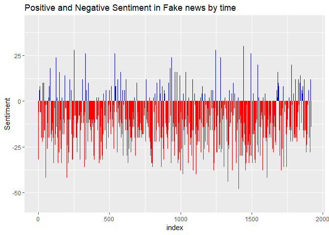

```r
Fake_to_plot <- Fake_words3 %>% inner_join(get_sentiments("bing")) %>%
  count( index = row_number() %/% 60, sentiment) %>%
  spread(sentiment, n, fill = 0) %>%
  mutate(sentiment = positive - negative)

ggplot(data = Fake_to_plot, aes(x = index, y = sentiment)) +
        geom_bar(aes(fill = sentiment>0),stat = 'identity', position = position_dodge()) +
        ylab("Sentiment") +
        ggtitle("Positive and Negative Sentiment in Fake news by time") +
        scale_color_manual(values = c("orange", "blue")) +
        scale_fill_manual(values = c("red", "blue"),guide = FALSE, breaks = c(TRUE, FALSE))
```

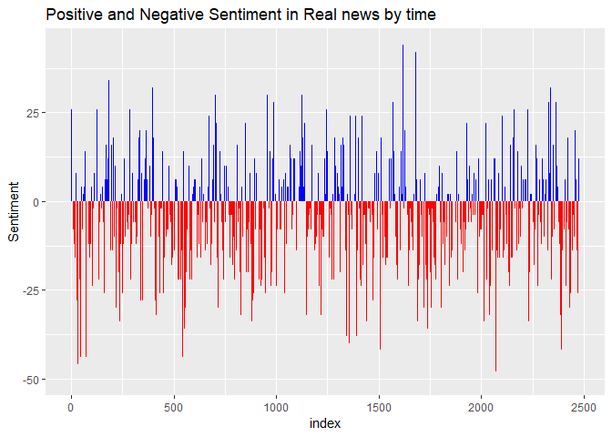

```r
Real_to_plot <- Real_words3 %>% inner_join(get_sentiments("bing")) %>%
  count( index = row_number() %/% 60, sentiment) %>%
  spread(sentiment, n, fill = 0) %>%
  mutate(sentiment = positive - negative)

ggplot(data = Real_to_plot, aes(x = index, y = sentiment)) +
        geom_bar(aes(fill = sentiment>0),stat = 'identity', position = position_dodge()) +
        ylab("Sentiment") +
        ggtitle("Positive and Negative Sentiment in Real news by time") +
        scale_color_manual(values = c("orange", "blue")) +
        scale_fill_manual(values = c("red", "blue"),guide = FALSE, breaks = c(TRUE, FALSE))
```

An interesting deduction is there are more positive words and paragraphs in Real new than fake.

## Find most common bigrams in Fake and Real news

Here we calculate the most common bigrams in fake news

```r
Fakenews_bis = fakes3 %>% filter(label=="FAKE") %>% select(text)
Fakenews_bis = Fakenews_bis %>% unnest_tokens(bigram, text, token = "ngrams", n = 2)
Fakenews_separated <- Fakenews_bis %>% separate(bigram, c("word1", "word2"), sep=" ")
Fakenews_bigram_filtered <- Fakenews_separated %>% filter(!word1 %in% stop_words$word) %>% filter(!word2 %in% stop_words$word)
Fakenews_bigram_counts <- Fakenews_bigram_filtered %>% count(word1, word2, sort = TRUE)
Fakenews_bigrams_united <- Fakenews_bigram_filtered %>% unite(bigram, word1, word2, sep = " ")
Fakenews_bigrams <- Fakenews_bigrams_united %>% count(bigram, sort=T) %>% filter(n>3)

hchart(head(Fakenews_bigrams,30) ,type = "column", title="Most common bigrams in fake news", hcaes(x = bigram, y=n))  %>% hc_add_theme(hc_theme_google())
```

[interactive chart not shown]

Here we calculate the most common bigrams in real news

```r
Realnews_bis = fakes3 %>% filter(label=="REAL") %>% select(text)
Realnews_bis = Realnews_bis %>% unnest_tokens(bigram, text, token = "ngrams", n = 2)
Realnews_separated <- Realnews_bis %>% separate(bigram, c("word1", "word2"), sep=" ")
Realnews_bigram_filtered <- Realnews_separated %>% filter(!word1 %in% stop_words$word) %>% filter(!word2 %in% stop_words$word)
Realnews_bigram_counts <- Realnews_bigram_filtered %>% count(word1, word2, sort = TRUE)
Realnews_bigrams_united <- Realnews_bigram_filtered %>% unite(bigram, word1, word2, sep = " ")
Realnews_bigrams <- Realnews_bigrams_united %>% count(bigram, sort=T) %>% filter(n>3)

hchart(head(Realnews_bigrams,30) ,type = "column", title="Most common bigrams in real news", hcaes(x = bigram, y=n))  %>% hc_add_theme(hc_theme_google())
```

[interactive chart not shown]

There’s many mentions of Obama’s name in real news, also the name Donald Trump has appeared more in real news than fake which is vice versa for fake news

# Clean the Data

Reading the raw csv, the data was getting tangled together (the text column was being shown on other columns) so we create a clean data frame for the news

```r
fakes = fakes1[-1]
row_indexes <- sample(1:nrow(fakes), nrow(fakes), replace = F)
fakes <- slice(fakes, row_indexes)

names(fakes)
```

```
##  [1] "ord_in_thread"      "author"             "published"
##  [4] "title"              "text"               "language"
##  [7] "crawled"            "site_url"           "country"
## [10] "domain_rank"        "thread_title"       "spam_score"
## [13] "main_img_url"       "replies_count"      "participants_count"
## [16] "likes"              "comments"           "shares"
## [19] "type"
```

As you can see we have 19 different columns for each article. Next we replace NA values with strings For domain rank, we replace NAs with 0 (we will make this factor, so NA is a new class)

```r
clean_fakes <- fakes %>%
  mutate(title = na.replace(title, "NoTitle")) %>%
  mutate(thread_title = na.replace(thread_title, "NoThread")) %>%
  mutate(text = na.replace(text, "NoText")) %>%
  mutate(author = na.replace(author, "NoAuthor")) %>%
  mutate(country = na.replace(country, "NoCountry")) %>%
  mutate(main_img_url = na.replace(main_img_url, "NoURL")) %>%
  mutate(domain_rank = na.replace(domain_rank, 0)) %>%
  mutate(domain_rank = as.factor(domain_rank))
```

Our first assumption is that words with all capital letters are suspicious and aren’t usually in a legit news article so we start by counting them.

```r
clean_fakes <- clean_fakes %>%
  mutate(caps_title = str_count(title, "\\b[A-Z]{2,}\\b")) %>%
  mutate(caps_thread = str_count(thread_title, "\\b[A-Z]{2,}\\b")) %>%
  mutate(caps_text = str_count(text, "\\b[A-Z]{2,}\\b"))
```

Next we compute the length of title, thread_title and text and also the number of exclamation points to see if there’s a correlation between the length of articles or header and number of exclamation points and its being fake.

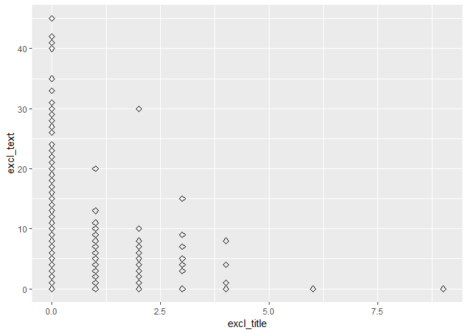

```r
clean_fakes <- clean_fakes %>%
  mutate(title_len = str_count(title)) %>%
  mutate(thread_len = str_count(thread_title)) %>%
  mutate(text_len = str_count(text)) %>%
  mutate(excl_title = str_count(title, "!")) %>%
  mutate(excl_thread = str_count(thread_title, "!")) %>%
  mutate(excl_text = str_count(text, "!")) %>%
  filter(language == "english")

ggplot(clean_fakes[clean_fakes$excl_text<50,], aes(x=excl_title, y=excl_text)) + geom_point(size=2, shape=23) + scale_color_brewer(palette="Dark2")
```

```r
col.factors <- c("language", "site_url")

clean_fakes <- clean_fakes %>%
  mutate_at(vars(language, site_url, country, type), funs(as.factor))

head(clean_fakes, 10)
```

```
##    ord_in_thread                 author                     published
## 1              0               REALdeal 2016-11-11T22:24:48.258+02:00
## 2              0 Nikolai Litovkin, RBTH 2016-10-28T13:31:15.199+03:00
## 3              0         Claire Bernish 2016-11-04T02:00:00.000+02:00
## 4              0           Steve Sailer 2016-11-08T18:36:52.467+02:00
## 5              0      Daniel Greenfield 2016-10-28T14:52:54.791+03:00
## 6              0           Steve Sailer 2016-11-05T10:03:00.000+02:00
## 7              0         Jason Howerton 2016-10-27T02:43:00.000+03:00
## 8              0          Activist Post 2016-10-27T19:20:39.827+03:00
## 9              0                        2016-11-09T18:09:00.000+02:00
## 10             0                        2016-11-16T05:23:59.305+02:00
##                                                                                                                                title
## 1                                                          Why Most People Are Deficient In Magnesium: The Signs and What You Can Do
## 2                                                                     Why Russiaâs army canât complete its modernization program
## 3                                            âAnti-Establishmentâ Trump Plans to Appoint Goldman Sachs and George Soros Insiders
```

[output cut: 106 more lines]

```r
clean_fakes %>% group_by(type) %>% count()
```

```
## # A tibble: 8 x 2
## # Groups:   type [8]
##   type           n
##   <fct>      <int>
## 1 bias         443
## 2 bs         10900
## 3 conspiracy   430
## 4 fake          19
## 5 hate         243
## 6 junksci      102
## 7 satire       146
## 8 state        120
```

as you can see we have many kinds of news:

Extreme Bias: Sources that traffic in political propaganda and gross distortions of fact.

BS: Sources that traffic in rumors, innuendo, and unverified claims.

Conspiracy Theory: Sources that are well-known promoters of kooky conspiracy theories.

Fake News: Sources that fabricate stories out of whole cloth with the intent of pranking the public.

Hate Group: Sources that actively promote racism, misogyny, homophobia, and other forms of discrimination.

Junk Science: Sources that promote pseudoscience, metaphysics, naturalistic fallacies, and other scientifically dubious claims.

State News: Sources in repressive states operating under government sanction.

```r
bias = clean_fakes[clean_fakes$type=="bias",]
bs = clean_fakes[clean_fakes$type=="bs",]
conspiracy = clean_fakes[clean_fakes$type=="conspiracy",]
fake = clean_fakes[clean_fakes$type=="fake",]
hate = clean_fakes[clean_fakes$type=="hate",]
junksci = clean_fakes[clean_fakes$type=="junksci",]
state = clean_fakes[clean_fakes$type=="state",]
```

## Types of fake news

our main interest is if each part of news is overall true or false but first we take a look at how wide our data is.

since computing sentiment for all the data takes a long time, you can comment the second line to get the analysis on all the data

```r
fake_subset = clean_fakes
fake_subset = sample_n(clean_fakes,6000)

sentiment_title <- get_nrc_sentiment(fake_subset$title)
sentiment_thread <- get_nrc_sentiment(fake_subset$thread_title)
sentiment_text <- get_nrc_sentiment(fake_subset$text)

# Include them in data
sentiments_all <- sentiment_text + sentiment_thread + sentiment_title
fake_subset <- cbind(fake_subset, sentiments_all)

# Remove some features
fake_subset$main_img_url <- NULL # We will use this later
fake_subset$title <- NULL
fake_subset$text <- NULL
fake_subset$thread_title <- NULL
```

We compute sentiment for words used in fake news for different categories. It’ll show which sentiments are mostly the ones used to lie to people with.

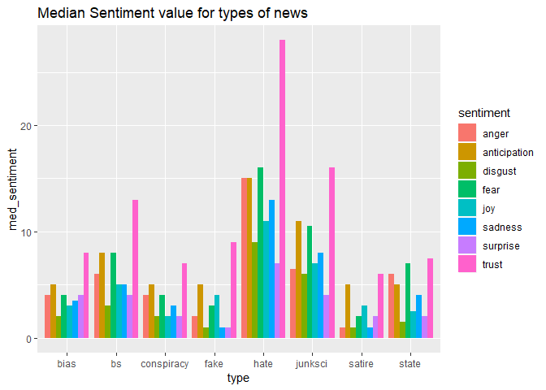

```r
sentiment_df <- cbind(fake_subset['type'], sentiments_all)  %>% select(-c(positive, negative))

med_sents <- sentiment_df %>%
  group_by(type) %>%
  summarise_all(funs(median)) %>%
  gather(key = sentiment, value = med_sentiment, -type) %>%
  mutate(sentiment = as.factor(sentiment))

ggplot(med_sents, aes(type, med_sentiment, fill = sentiment)) +
  geom_bar(stat = "identity", position = "dodge") + ggtitle("Median Sentiment value for types of news")
```

Then We calculate the Sd value of each sentiment by type

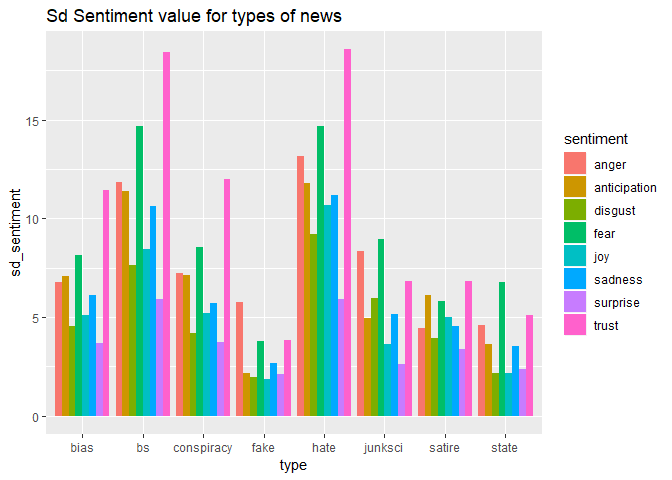

```r
sd_sent <- sentiment_df %>%
  group_by(type) %>%
  summarise_all(funs(sd)) %>%
  gather(key = sentiment, value = sd_sentiment, -type) %>%
  mutate(sentiment = as.factor(sentiment))

ggplot(sd_sent, aes(type, sd_sentiment, fill = sentiment)) +
  geom_bar(stat = "identity", position = "dodge") + ggtitle("Sd Sentiment value for types of news")
```

Now we find the most used words for “bs” type of fake news and draw a wordcloud

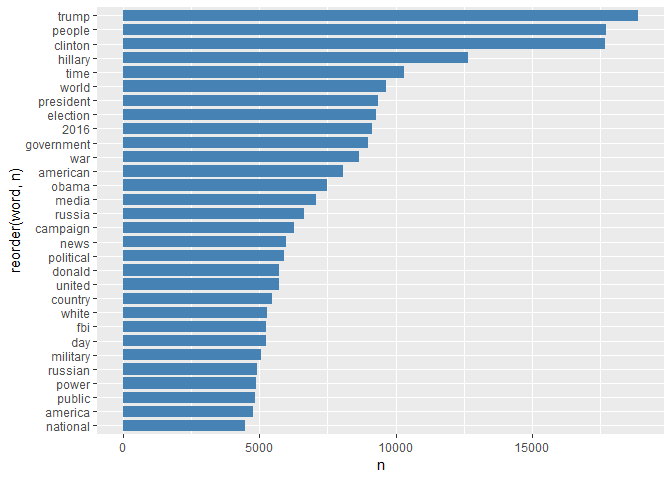

```r
words_in_bs_text <- clean_fakes[which(clean_fakes$type=="bs"),][5]
clean_bs_text <- words_in_bs_text %>% unnest_tokens(word, text) %>% anti_join(stop_words)
clean_bs_counts <- clean_bs_text %>% count(word, sort = TRUE)
clean_bs_counts = clean_bs_counts[which(grepl('^[A-Za-z0-9]+$',clean_bs_counts$word)==T),] %>% arrange(-n)

ggplot(data=head(clean_bs_counts,30), aes(x = reorder(word,n), y=n)) +
  geom_bar(stat="identity", width=0.8, fill="steelblue")+
  scale_fill_brewer(palette="blues") + coord_flip()
```

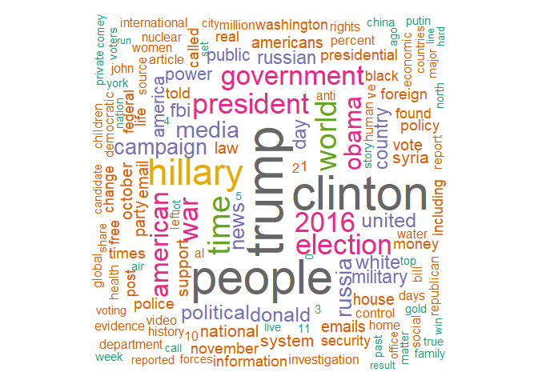

```r
wordcloud(words = clean_bs_counts$word, freq = clean_bs_counts$n, min.freq = 2,
          max.words=200, random.order=FALSE, rot.per=0.35, colors=brewer.pal(8, "Dark2"))
```

We do the same thing for “bias” news

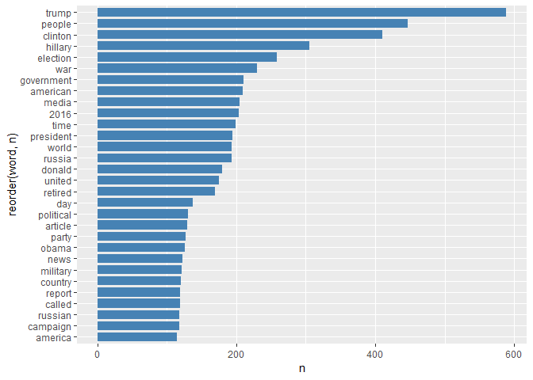

```r
words_in_bias_text <- clean_fakes[which(fakes1$type=="bias"),][5]
clean_bias_text <- words_in_bias_text %>% unnest_tokens(word, text) %>% anti_join(stop_words)
clean_bias_counts <- clean_bias_text %>% count(word, sort = TRUE)
clean_bias_counts = clean_bias_counts[which(grepl('^[A-Za-z0-9]+$',clean_bias_counts$word)==T),] %>% arrange(-n)

ggplot(data=head(clean_bias_counts,30), aes(x = reorder(word,n), y=n)) +
  geom_bar(stat="identity", width=0.8, fill="steelblue")+
  scale_fill_brewer(palette="blues") + coord_flip()
```

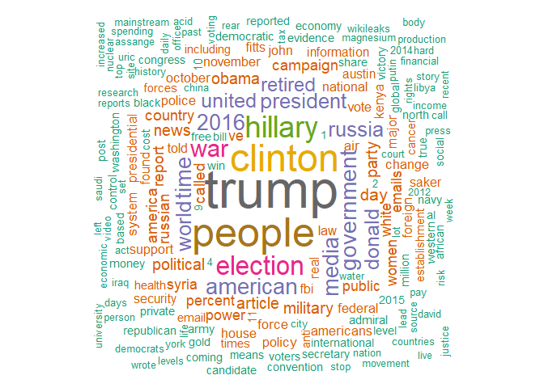

```r
wordcloud(words = clean_bias_counts$word, freq = clean_bias_counts$n, min.freq = 2,
          max.words=200, random.order=FALSE, rot.per=0.35,
          colors=brewer.pal(8, "Dark2"))
```

And the same for “conspiracy” news

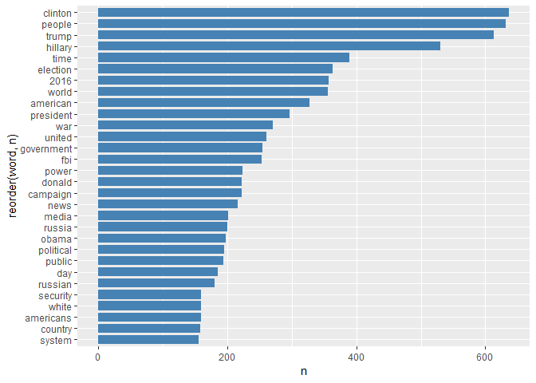

```r
words_in_conspiracy_text <- clean_fakes[which(fakes1$type=="conspiracy"),][5]
clean_conspiracy_text <- words_in_conspiracy_text %>% unnest_tokens(word, text) %>% anti_join(stop_words)
clean_conspiracy_counts <- clean_conspiracy_text %>% count(word, sort = TRUE)
clean_conspiracy_counts = clean_conspiracy_counts[which(grepl('^[A-Za-z0-9]+$',clean_conspiracy_counts$word)==T),] %>% arrange(-n)

ggplot(data=head(clean_conspiracy_counts,30), aes(x = reorder(word,n), y=n)) +
  geom_bar(stat="identity", width=0.8, fill="steelblue")+
  scale_fill_brewer(palette="blues") + coord_flip()
```

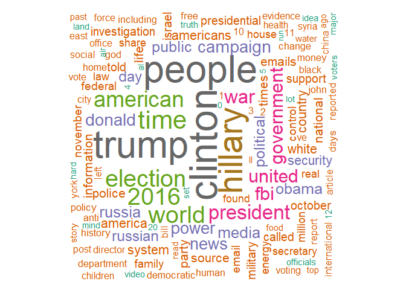

```r
wordcloud(words = clean_conspiracy_counts$word, freq = clean_conspiracy_counts$n, min.freq = 2,
          max.words=200, random.order=FALSE, rot.per=0.35,
          colors=brewer.pal(8, "Dark2"))
```

Also for the “hate” type

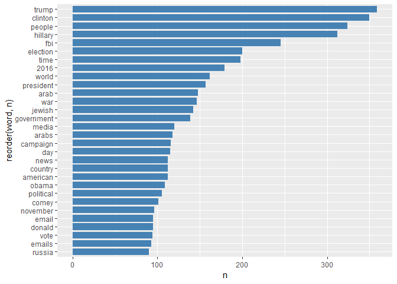

```r
words_in_hate_text <- clean_fakes[which(fakes1$type=="hate"),][5]
clean_hate_text <- words_in_hate_text %>% unnest_tokens(word, text) %>% anti_join(stop_words)
clean_hate_counts <- clean_hate_text %>% count(word, sort = TRUE)
clean_hate_counts = clean_hate_counts[which(grepl('^[A-Za-z0-9]+$',clean_hate_counts$word)==T),] %>% arrange(-n)

ggplot(data=head(clean_hate_counts,30), aes(x = reorder(word,n), y=n)) +
  geom_bar(stat="identity", width=0.8, fill="steelblue")+
  scale_fill_brewer(palette="blues") + coord_flip()
```

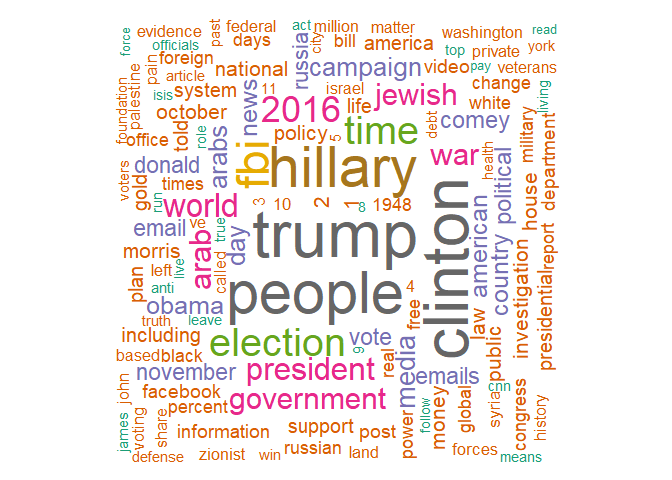

```r
wordcloud(words = clean_hate_counts$word, freq = clean_hate_counts$n, min.freq = 2,
          max.words=200, random.order=FALSE, rot.per=0.35,
          colors=brewer.pal(8, "Dark2"))
```

now we draw a plot for when and how much of each kind of data were published and crawled

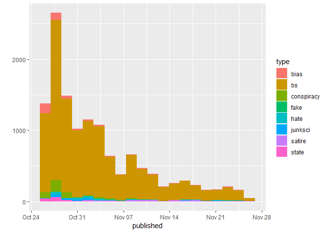

```r
tfake <- mutate(fakes, published = ymd_hms(published))
qplot(x = published, data = tfake, fill = type, bins = 20)
```

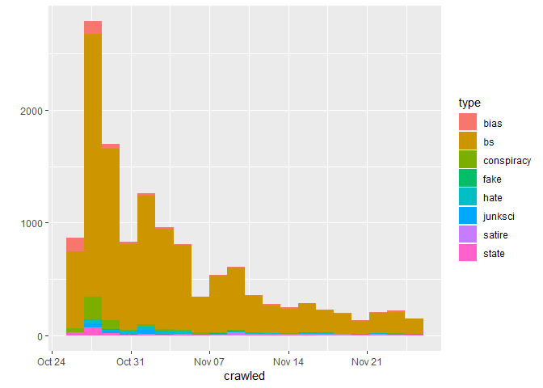

```r
sfake <- mutate(fakes, crawled = ymd_hms(crawled))
qplot(x = crawled, data = sfake, fill = type, bins = 20)
```

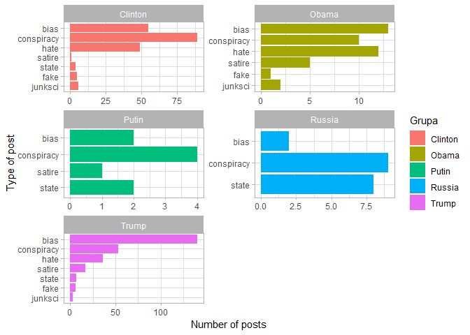

```r
check_most_fakes = clean_fakes %>% mutate(Grupa =
  ifelse(grepl("Trump", clean_fakes$title)==TRUE | grepl("Donald", clean_fakes$title)==TRUE,"Trump",
  ifelse(grepl("Hillary", clean_fakes$title)==TRUE | grepl("Clinton", clean_fakes$title)==TRUE,"Clinton",
  ifelse(grepl("Barack", clean_fakes$title)==TRUE | grepl("Obama", clean_fakes$title)==TRUE,"Obama",
  ifelse(grepl("Vladimir", clean_fakes$title)==TRUE | grepl("Putin", clean_fakes$title)==TRUE,"Putin",
  ifelse(grepl("Russia", clean_fakes$title)==TRUE,"Russia",0))))))

filtered_check_most_fakes1 = check_most_fakes %>%
  filter(Grupa == 'Clinton' | Grupa == 'Trump' | Grupa == 'Obama' | Grupa == 'Putin' | Grupa == 'Russia') %>%
  group_by(type,Grupa) %>%
  count(Grupa) %>%
  filter(type!='bs')

ggplot(filtered_check_most_fakes1, aes(x=reorder(type, n), y=n, fill = Grupa)) +
  geom_col() +
  facet_wrap(~Grupa, ncol = 2, scales = "free") +
  theme_light() +
  ylab("Number of posts") +
  xlab("Type of post") +
  coord_flip()
```

Now we filter the news with clinton and trump in them by type of lie

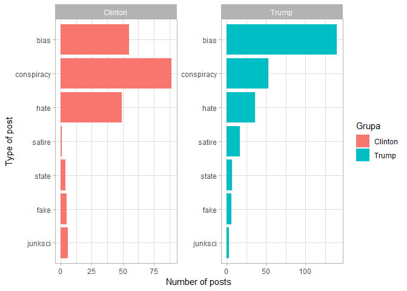

```r
filtered_check_most_fakes2 = check_most_fakes %>% filter(Grupa == 'Clinton' | Grupa == 'Trump') %>%
  group_by(type,Grupa) %>% count(Grupa) %>% filter(type!='bs')

ggplot(filtered_check_most_fakes2, aes(x=reorder(type, n), y=n, fill = Grupa)) +
  geom_col() +
  facet_wrap(~Grupa, ncol = 2, scales = "free") +
  theme_light() +
  ylab("Number of posts") +
  xlab("Type of post") +
  coord_flip()
```

Then we compute number of likes distributed by type

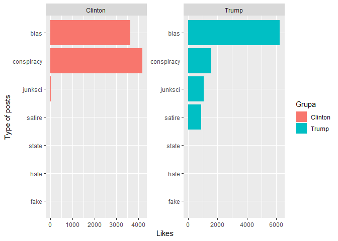

```r
filtered_check_most_fakes3 = check_most_fakes %>% select(Grupa, type, likes, comments) %>% filter(Grupa=="Trump" | Grupa=="Clinton") %>% group_by(Grupa, type) %>%
  summarise(Likes=sum(likes)) %>% filter(type!='bs')

ggplot(filtered_check_most_fakes3, aes(reorder(type, Likes), Likes, fill = Grupa)) +
  geom_col() +
  facet_wrap(~Grupa, ncol = 2, scales = "free") +
  xlab("Type of posts") +
  coord_flip()
```

Then we show most frequent words for Clinton by type (except bs).

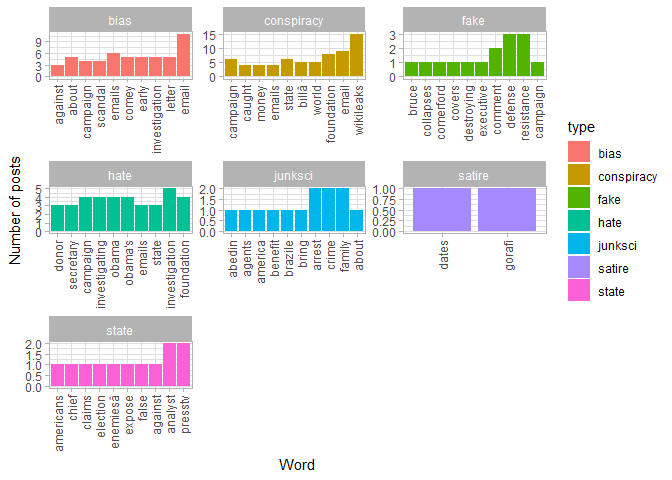

```r
clinton_words = check_most_fakes %>% filter(Grupa=="Clinton") %>% select(type, title)
clinton_words = data_frame(type = clinton_words$type, text = clinton_words$title) %>% unnest_tokens(word, text)
clinton_words = clinton_words %>% count(type, word, sort = TRUE) %>% mutate(len=nchar(word)) %>% filter(len>4)
clinton_words$check = ifelse(grepl("hillary", clinton_words$word)==TRUE | grepl("clinton", clinton_words$word)==TRUE,1,0)
clinton_words = clinton_words %>% filter(check==0 & type!='bs') %>% group_by_(~ type) %>%
  do(head(., n = 10))

ggplot(clinton_words, aes(x=reorder(word,n), y=n, fill = type)) + geom_col() +
  facet_wrap(~type,ncol = 3, scales = "free") +
  theme_light() +
  ylab("Number of posts") +
  xlab("Word") +
  theme(axis.text.x=element_text(angle=90,hjust=1,vjust=0.5))
```

And most frequent words for Clinton in bs type.

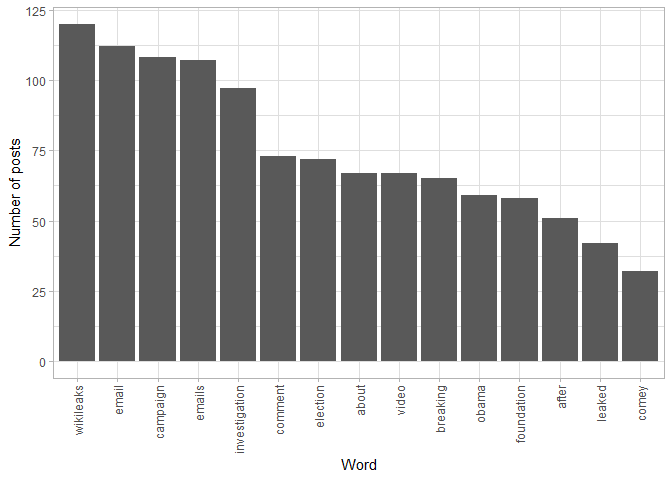

```r
clinton_bs = check_most_fakes %>% filter(Grupa=="Clinton") %>% select(type, title)
clinton_bs = data_frame(type = clinton_bs$type, text = clinton_bs$title) %>% unnest_tokens(word, text)
clinton_bs = clinton_bs %>% count(type, word, sort = TRUE) %>% mutate(len=nchar(word)) %>% filter(len>4)
clinton_bs$check = ifelse(grepl("clinton", clinton_bs$word)==TRUE | grepl("hillary", clinton_bs$word)==TRUE,1,0)
clinton_bs = clinton_bs %>% filter(check==0 & type=='bs') %>% head(15)

ggplot(clinton_bs, aes(x=reorder(word,-n),y=n)) + geom_col() +
  theme_light() +
  ylab("Number of posts") +
  xlab("Word") +
  theme(axis.text.x=element_text(angle=90,hjust=1,vjust=0.5))
```

Next we show most frequent words for Trump by type (except bs).

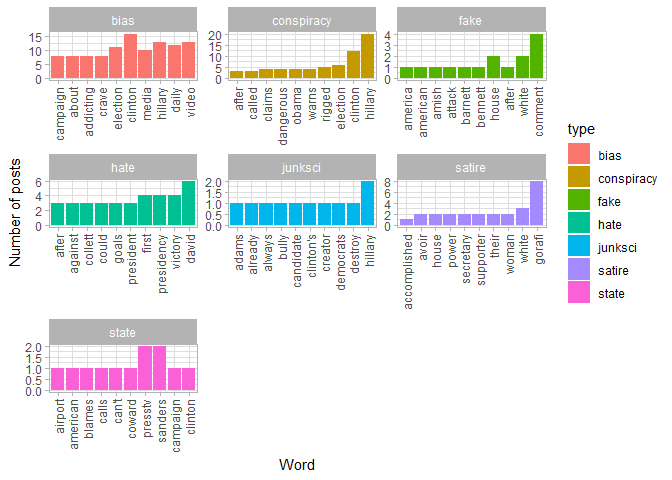

```r
trump_words = check_most_fakes %>% filter(Grupa=="Trump") %>% select(type, title)
trump_words = data_frame(type = trump_words$type, text = trump_words$title) %>% unnest_tokens(word, text)
trump_words = trump_words %>% count(type, word, sort = TRUE) %>% mutate(len=nchar(word)) %>% filter(len>4)
trump_words$check = ifelse(grepl("donald", trump_words$word)==TRUE | grepl("trump", trump_words$word)==TRUE,1,0)
trump_words = trump_words %>% filter(check==0 & type!='bs') %>% group_by_(~ type) %>%
  do(head(., n = 10))

ggplot(trump_words, aes(x=reorder(word,n), y=n, fill = type)) + geom_col() +
  facet_wrap(~type,ncol = 3, scales = "free") +
  theme_light() +
  ylab("Number of posts") +
  xlab("Word") +
  theme(axis.text.x=element_text(angle=90,hjust=1,vjust=0.5))
```

And most frequent words for Trump in bs type.

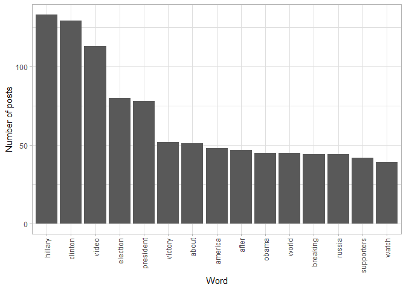

```r
trump_bs = check_most_fakes %>% filter(Grupa=="Trump") %>% select(type, title)
trump_bs = data_frame(type = trump_bs$type, text = trump_bs$title) %>% unnest_tokens(word, text)
trump_bs = trump_bs %>% count(type, word, sort = TRUE) %>% mutate(len=nchar(word)) %>% filter(len>4)
trump_bs$check = ifelse(grepl("donald", trump_bs$word)==TRUE | grepl("trump", trump_bs$word)==TRUE,1,0)
trump_bs = trump_bs %>% filter(check==0 & type=='bs') %>% head(15)

ggplot(trump_bs, aes(x=reorder(word,-n),y=n)) + geom_col() +
  theme_light() +
  ylab("Number of posts") +
  xlab("Word") +
  theme(axis.text.x=element_text(angle=90,hjust=1,vjust=0.5))
```

The rpart programs build classification or regression models of a very general structure using a two stage procedure

you can read more about it here: https://cran.r-project.org/web/packages/rpart/vignettes/longintro.pdf

we want to create a model to guess the type of data.

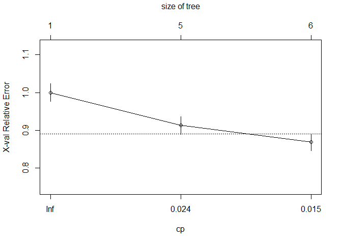

```r
test_model <- rpart(formula = type ~ ord_in_thread + language + country + spam_score + replies_count + participants_count + likes + comments + shares,
                    data = fakes1, method = "class", # Classification
                    parms = list(split = "information"),
                    control = rpart.control(cp = 0.01, maxcompete = 3, maxsurrogate = 3,
                                            xval = 20, maxdepth = 4))
plotcp(test_model)
```

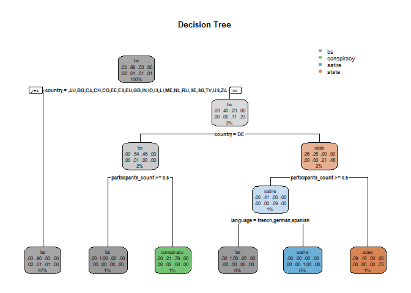

```r
rpart.plot(test_model, main = "Decision Tree", box.palette = list("Gy", "Gn", "Bu", "Bn", "Or", "Rd", "Gy", "Pu"))
```

```r
summary(test_model)
```

```
## Call:
## rpart(formula = type ~ ord_in_thread + language + country + spam_score +
##     replies_count + participants_count + likes + comments + shares,
##     data = fakes1, method = "class", parms = list(split = "information"),
##     control = rpart.control(cp = 0.01, maxcompete = 3, maxsurrogate = 3,
##         xval = 20, maxdepth = 4))
##   n= 12999
##
##           CP nsplit rel error    xerror       xstd
## 1 0.02676399      0 1.0000000 1.0000000 0.02422067
## 2 0.02123424      4 0.8891838 0.9124088 0.02326810
## 3 0.01000000      5 0.8679496 0.8679496 0.02275944
##
## Variable importance
##            country participants_count           language
##                 62                 18                 10
##      replies_count      ord_in_thread         spam_score
##                  5                  3                  2
##
## Node number 1: 12999 observations,    complexity param=0.02676399
##   predicted class=bs          expected loss=0.115932  P(node) =1
##     class counts:   443 11492   430    19   246   102   146   121
##    probabilities: 0.034 0.884 0.033 0.001 0.019 0.008 0.011 0.009
##   left son=2 (12561 obs) right son=3 (438 obs)
##   Primary splits:
##       country            splits as  LLLLLLRLLLRLLLRLLLLLLLLLL, improve=563.6348, (0 missing)
##       likes              < 0.5   to the left,  improve=419.0213, (0 missing)
##       shares             < 0.5   to the left,  improve=419.0213, (0 missing)
##       participants_count < 0.5   to the right, improve=318.8241, (0 missing)
##
## Node number 2: 12561 observations
##   predicted class=bs          expected loss=0.09911631  P(node) =0.9663051
##     class counts:   431 11316   330    19   246   100   100    19
##    probabilities: 0.034 0.901 0.026 0.002 0.020 0.008 0.008 0.002
##
## Node number 3: 438 observations,    complexity param=0.02676399
##   predicted class=bs          expected loss=0.5981735  P(node) =0.0336949
##     class counts:    12   176   100     0     0     2    46   102
##    probabilities: 0.027 0.402 0.228 0.000 0.000 0.005 0.105 0.233
##   left son=6 (224 obs) right son=7 (214 obs)
```

[output cut: 55 more lines]

```
##
## Node number 15: 136 observations
##   predicted class=state       expected loss=0.25  P(node) =0.01046234
##     class counts:    12    22     0     0     0     0     0   102
##    probabilities: 0.088 0.162 0.000 0.000 0.000 0.000 0.000 0.750
##
## Node number 28: 32 observations
##   predicted class=bs          expected loss=0  P(node) =0.002461728
##     class counts:     0    32     0     0     0     0     0     0
##    probabilities: 0.000 1.000 0.000 0.000 0.000 0.000 0.000 0.000
##
## Node number 29: 46 observations
##   predicted class=satire      expected loss=0  P(node) =0.003538734
##     class counts:     0     0     0     0     0     0    46     0
##    probabilities: 0.000 0.000 0.000 0.000 0.000 0.000 1.000 0.000
```